# 03_dataanalyses

# Everything

## TODO before

ToDo 06.02.2019

- Datenwrangling fertig durchgehen (x)
- Analyse in ein Skript packen (x)
- Grafikidee: HR für admiration und rivalry? –> Autor geschrieben
- survival Grafiken nur für Admiration / Rivalry (x)
- schönen Output generieren

Fragen an Tanja:

- Analysen jetzt mit z-standardisiertem NARQ, weil schöner fürs Plotten und leichter zu interpretieren –> Bist du einverstanden?
- Beim Median-Split und bei den Quartilen wissen wir nicht genau, was wir mit den Personen machen sollen, die genau auf der Kippe zwischen zwei Gruppen stehen?
- Extremgruppenanalyse: Wir haben jetzt die beiden Gruppen unteres Quartile und oberes Quartil genommen, da die Gruppengrößen sonst viel zu klein sind. Sind aber mit dem approach nicht so zufrieden…
- Survival Analysen Plots nicht so aussagekräftig –> evtl. bräuchte man dafür doch die Latent Class Analysis, um etwas aussagen zu können…
- Wenn survival Plots ja, sollen wir die x-Achse anpassen?

Furthur to do: * analyses including future prospects

## Planned Analysis

### Relationship Entry

- Model 1: rel_entry ~ NARQ_z + cluster(session)
- Model 2: rel_entry ~ NARQ_ADM_z + NARQ_RIV_z + cluster(session)
- -> Plot Relative Hazards for ADM und RIV
- Model 3: rel_entry ~ NARQ_ADM_z + NARQ_RIV_z + gender/sex + age + cluster(session)
- -> Plot Relative Hazards for ADM und RIV
- Model 4: rel_entry ~ NARQ_ADM_group + NARQ_RIV_group + gender/sex + age + cluster(session)
- -> Plot survival analysis for groups
- Model 5: rel_entry ~ NARQ_ADM_quartil + NARQ_RIV_quartil + gender/sex + age + cluster(session)
- -> Plot survival analysis for quartils
- Model 6: rel_entry ~ NARQ_ADM_extreme + NARQ_RIV_extreme + gender/sex + age + cluster(session)
- -> Plot survival analysis for extremes

### Relationship End

- Model 1: rel_end ~ NARQ_z + cluster(session)
- Model 2: rel_end ~ NARQ_ADM_z + NARQ_RIV_z + cluster(session)
- -> Plot Relative Hazards for ADM und RIV
- Model 3: rel_end ~ NARQ_ADM_z + NARQ_RIV_z + gender/sex + age + cluster(session)
- -> Plot Relative Hazards for ADM und RIV
- Model 4: rel_end ~ NARQ_ADM_group + NARQ_RIV_group + gender/sex + age + cluster(session)
- -> Plot survival analysis for groups
- Model 5: rel_end ~ NARQ_ADM_quartil + NARQ_RIV_quartil + gender/sex + age + cluster(session)
- -> Plot survival analysis for quartils
- Model 6: rel_end ~ NARQ_ADM_extreme + NARQ_RIV_extreme + gender/sex + age + cluster(session)
- -> Plot survival analysis for extremes

## Packages

```r
library(lm.beta)
library(survival)
library(coxme)
library(survminer)
library(simPH)
library(formr)
library(dplyr)
select = dplyr::select
```

## Data

```r
surv_data = read.csv("ImportedData/data_exclusive_clean.csv")
```

### Preperations before analyses

#### Convert date into days

Time of relationship/being single has to be in days

```r
surv_data = surv_data %>%
  mutate(single_start = as.Date(single_start),
         single_end = as.Date(single_end),
         start = as.Date(start),
         end = as.Date(end),
         single_start_d = 0,
         single_end_d = single_end - single_start,
         rel_start_d = 0,
         rel_end_d = end - start,
 single_end_d = ifelse(single_end_d == 0, 1, single_end_d), # two people started a new relationship at the same day they ended their old one, survival analyses can not believe that --> so we set it at 1 day)
  rel_end_d = ifelse(rel_end_d == 0, 1, rel_end_d)) # 27 people had ended a relationship and filled out survey the same day (so right censored data) --> that's why we had to add 1 (day) to "rel_end_d"
```

#### Form z-standardized NARQ

```r
surv_data = surv_data %>%
  mutate(NARQ_scale_z = as.numeric(scale(NARQ_scale, center = T, scale = T)),
         NARQ_ADM_z = as.numeric(scale(NARQ_ADM, center = T, scale = T)),
         NARQ_RIV_z = as.numeric(scale(NARQ_RIV, center = T, scale = T)))
```

#### NARQ Groups

```r
##NARQ_scale
median_NARQ_scale = median(surv_data$NARQ_scale, na.rm = T)
surv_data = surv_data %>%
  mutate(NARQ_group = ifelse(NARQ_scale <= median_NARQ_scale, "low",
                             ifelse(is.na(NARQ_scale), NA, "high")),
         NARQ_group = as.factor(NARQ_group))

##NARQ_ADM
median_NARQ_ADM = median(surv_data$NARQ_ADM, na.rm = T)
surv_data = surv_data %>%
  mutate(NARQ_ADM_group = ifelse(NARQ_ADM <= median_NARQ_ADM, "low",
                             ifelse(is.na(NARQ_ADM), NA, "high")),
         NARQ_ADM_group = as.factor(NARQ_ADM_group))

##NARQ_RIV
median_NARQ_RIV = median(surv_data$NARQ_RIV, na.rm = T)
surv_data = surv_data %>%
  mutate(NARQ_RIV_group = ifelse(NARQ_RIV <= median_NARQ_RIV, "low",
                             ifelse(is.na(NARQ_RIV), NA, "high")),
         NARQ_RIV_group = as.factor(NARQ_RIV_group))
```

#### NARQ quartiles

```r
#NARQ_scale
NARQ_qu_25 <- quantile(surv_data$NARQ_scale, c(0.25), na.rm = T)
NARQ_qu_50 <- quantile(surv_data$NARQ_scale, c(0.50), na.rm = T)
NARQ_qu_75 <- quantile(surv_data$NARQ_scale, c(0.75), na.rm = T)

surv_data = surv_data %>%
  mutate(NARQ_quartil = ifelse(NARQ_scale <= NARQ_qu_25, 1,
                            ifelse(NARQ_scale <= NARQ_qu_50 & NARQ_scale > NARQ_qu_25, 2,
                                   ifelse(NARQ_scale <= NARQ_qu_75 & NARQ_scale > NARQ_qu_50, 3,
                                       ifelse(is.na(NARQ_scale), NA, 4)))),
         NARQ_quartil = as.factor(NARQ_quartil))

#NARQ_ADM
ADM_qu_25 <- quantile(surv_data$NARQ_ADM, c(0.25), na.rm = T)
ADM_qu_50 <- quantile(surv_data$NARQ_ADM, c(0.50), na.rm = T)
ADM_qu_75 <- quantile(surv_data$NARQ_ADM, c(0.75), na.rm = T)

surv_data = surv_data %>%
  mutate(NARQ_ADM_quartil = ifelse(NARQ_ADM <= ADM_qu_25, 1,
                              ifelse(NARQ_ADM <= ADM_qu_50 & NARQ_ADM > ADM_qu_25, 2,
                                   ifelse(NARQ_ADM <= ADM_qu_75 & NARQ_ADM > ADM_qu_50, 3,
                                       ifelse(is.na(NARQ_ADM), NA, 4)))),
         NARQ_ADM_quartil = as.factor(NARQ_ADM_quartil))

#NARQ_RIV
RIV_qu_25 <- quantile(surv_data$NARQ_RIV, c(0.25), na.rm = T)
RIV_qu_50 <- quantile(surv_data$NARQ_RIV, c(0.50), na.rm = T)
RIV_qu_75 <- quantile(surv_data$NARQ_RIV, c(0.75), na.rm = T)

surv_data = surv_data %>%
mutate(NARQ_RIV_quartil = ifelse(NARQ_RIV <= RIV_qu_25, 1,
                              ifelse(NARQ_RIV <= RIV_qu_50 & NARQ_RIV > RIV_qu_25, 2,
                                   ifelse(NARQ_RIV <= RIV_qu_75 & NARQ_RIV > RIV_qu_50, 3,
                                       ifelse(is.na(NARQ_RIV), NA, 4)))),
         NARQ_RIV_quartil = as.factor(NARQ_RIV_quartil))
```

#### NARQ Extremes

```r
# NARQ scale
surv_data = surv_data %>%
  mutate(NARQ_scale_extreme = ifelse(NARQ_scale <= NARQ_qu_25, "low",
                                     ifelse(NARQ_scale >= NARQ_qu_75, "high", NA)))

table(surv_data$NARQ_scale_extreme)
```

```
##
## high  low
##  305  324
```

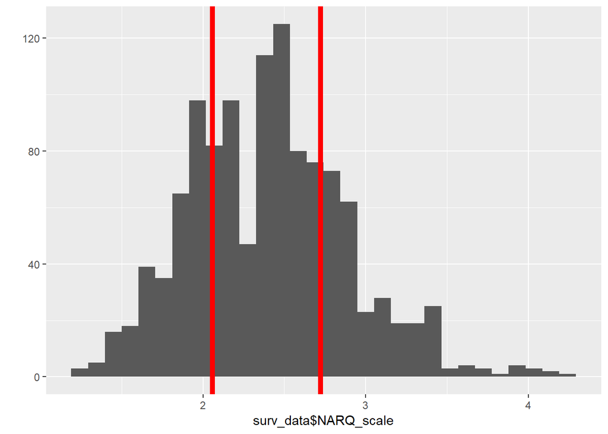

```r
qplot(surv_data$NARQ_scale) + geom_vline(xintercept = NARQ_qu_25, color = "red", size = 2) + geom_vline(xintercept = NARQ_qu_75, color = "red", size = 2)
```

```r
# Admiration
surv_data = surv_data %>%
  mutate(NARQ_ADM_extreme = ifelse(NARQ_ADM <= ADM_qu_25, "low",
                                     ifelse(NARQ_ADM >= ADM_qu_75, "high", NA)))

table(surv_data$NARQ_ADM_extreme)
```

```
##
## high  low
##  328  312
```

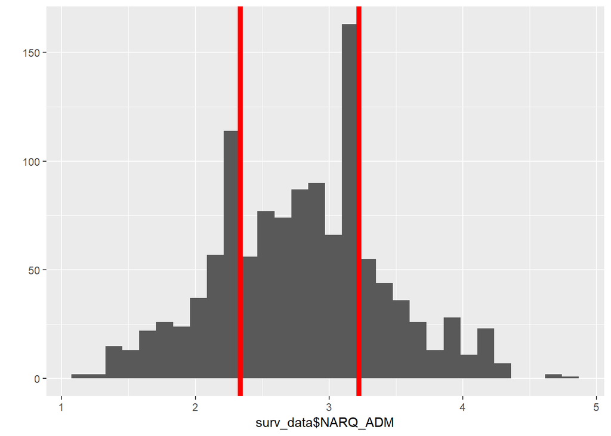

```r
qplot(surv_data$NARQ_ADM) + geom_vline(xintercept = ADM_qu_25, color = "red", size = 2) + geom_vline(xintercept = ADM_qu_75, color = "red", size = 2)
```

```r
# Rivalry
surv_data = surv_data %>%
  mutate(NARQ_RIV_extreme = ifelse(NARQ_RIV <= RIV_qu_25, "low",
                                     ifelse(NARQ_RIV >= RIV_qu_75, "high", NA)))

table(surv_data$NARQ_RIV_extreme)
```

```
##
## high  low
##  370  363
```

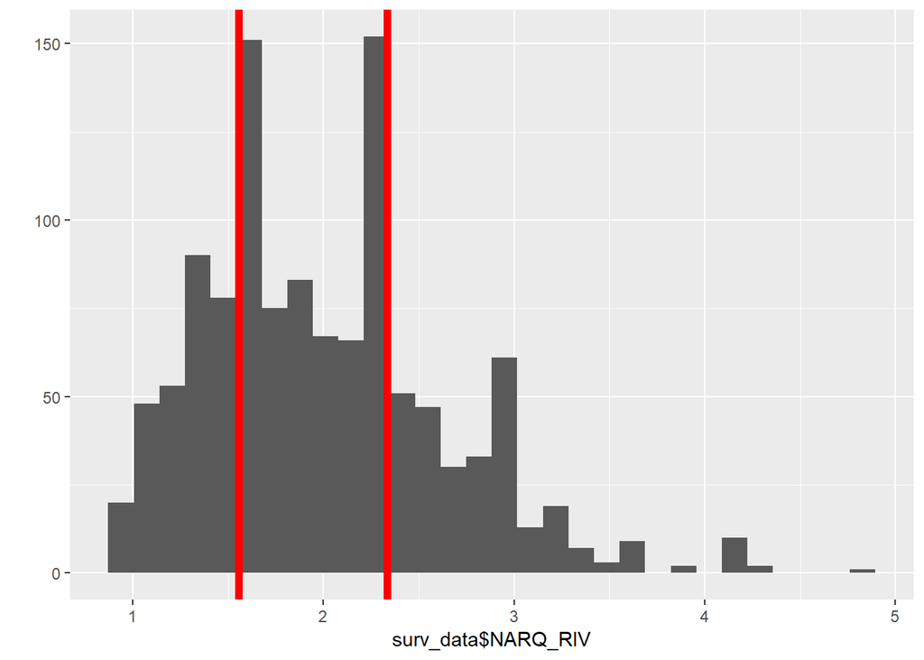

```r
qplot(surv_data$NARQ_RIV) + geom_vline(xintercept = RIV_qu_25, color = "red", size = 2) + geom_vline(xintercept = RIV_qu_75, color = "red", size = 2)
```

## Relationship Start

### Model 1

rel_entry ~ NARQ_z + cluster(session)

```r
start_narq_con.1 <- coxph(Surv(single_start_d, single_end_d, event_start) ~
                            NARQ_scale_z + cluster(session), data = surv_data)
summary(start_narq_con.1)
```

```
## Call:
## coxph(formula = Surv(single_start_d, single_end_d, event_start) ~
##     NARQ_scale_z + cluster(session), data = surv_data)
##
##   n= 1171, number of events= 621
##
##                 coef exp(coef) se(coef) robust se     z Pr(>|z|)
## NARQ_scale_z 0.15628   1.16915  0.04064   0.04497 3.475 0.000511 ***
## ---
## Signif. codes:  0 '***' 0.001 '**' 0.01 '*' 0.05 '.' 0.1 ' ' 1
##
##              exp(coef) exp(-coef) lower .95 upper .95
## NARQ_scale_z     1.169     0.8553     1.071     1.277
##
## Concordance= 0.541  (se = 0.013 )
## Rsquare= 0.012   (max possible= 0.999 )
## Likelihood ratio test= 14.42  on 1 df,   p=1e-04
## Wald test            = 12.08  on 1 df,   p=5e-04
## Score (logrank) test = 14.78  on 1 df,   p=1e-04,   Robust = 11.66  p=6e-04
##
##   (Note: the likelihood ratio and score tests assume independence of
##      observations within a cluster, the Wald and robust score tests do not).
```

```r
## Should not be significant
cox.zph(start_narq_con.1)
```

```
##                 rho chisq     p
## NARQ_scale_z 0.0244 0.462 0.497
```

```r
testPH_start_narq_con.1 <- ggcoxzph(cox.zph(start_narq_con.1))
```

### Model 2

rel_entry ~ NARQ_ADM_z + NARQ_RIV_z + cluster(session)

```r
start_narq_con.2 <- coxph(Surv(single_start_d, single_end_d, event_start) ~
                            NARQ_ADM_z + NARQ_RIV_z + cluster(session), data = surv_data)
summary(start_narq_con.2)
```

```
## Call:
## coxph(formula = Surv(single_start_d, single_end_d, event_start) ~
##     NARQ_ADM_z + NARQ_RIV_z + cluster(session), data = surv_data)
##
##   n= 1171, number of events= 621
##
##                 coef exp(coef)  se(coef) robust se      z Pr(>|z|)
## NARQ_ADM_z  0.205433  1.228056  0.041372  0.045182  4.547 5.45e-06 ***
## NARQ_RIV_z -0.004662  0.995349  0.042142  0.046598 -0.100     0.92
## ---
## Signif. codes:  0 '***' 0.001 '**' 0.01 '*' 0.05 '.' 0.1 ' ' 1
##
##            exp(coef) exp(-coef) lower .95 upper .95
## NARQ_ADM_z    1.2281     0.8143    1.1240     1.342
## NARQ_RIV_z    0.9953     1.0047    0.9085     1.091
##
## Concordance= 0.555  (se = 0.013 )
## Rsquare= 0.021   (max possible= 0.999 )
## Likelihood ratio test= 25.24  on 2 df,   p=3e-06
## Wald test            = 21.12  on 2 df,   p=3e-05
## Score (logrank) test = 25.43  on 2 df,   p=3e-06,   Robust = 20.57  p=3e-05
##
##   (Note: the likelihood ratio and score tests assume independence of
##      observations within a cluster, the Wald and robust score tests do not).
```

```r
## Should not be significant
cox.zph(start_narq_con.2)
```

```
##                 rho  chisq     p
## NARQ_ADM_z  0.02891 0.6199 0.431
## NARQ_RIV_z -0.00391 0.0127 0.910
## GLOBAL           NA 0.6202 0.733
```

```r
testPH_start_narq_con.2 <- ggcoxzph(cox.zph(start_narq_con.2))
```

### Plot Relative Hazards for ADM und RIV

```r
rh_start_narq_con.2 <- coxph(Surv(single_start_d, single_end_d, event_start) ~
                            NARQ_ADM_z + NARQ_RIV_z + cluster(session), data = surv_data)

Sim_rh_start_narq_con.adm <- coxsimLinear(rh_start_narq_con.2, b = "NARQ_ADM_z",
                                        Xj = seq(-3, 3, by = 0.5), nsim = 100)
```

```
## All Xl set to 0.
```

```r
Sim_rh_start_narq_con.adm = simGG(Sim_rh_start_narq_con.adm, xlab = "Units of admiration from mean in SD", ylab = "Relative Hazards Comparing to Mean")

Sim_rh_start_narq_con.adm.data = Sim_rh_start_narq_con.adm$data %>%
  mutate(group = "Admiration")

Sim_rh_start_narq_con.riv <- coxsimLinear(rh_start_narq_con.2, b = "NARQ_RIV_z",
                                        Xj = seq(-3, 3, by = 0.5), nsim = 100)
```

```
## All Xl set to 0.
```

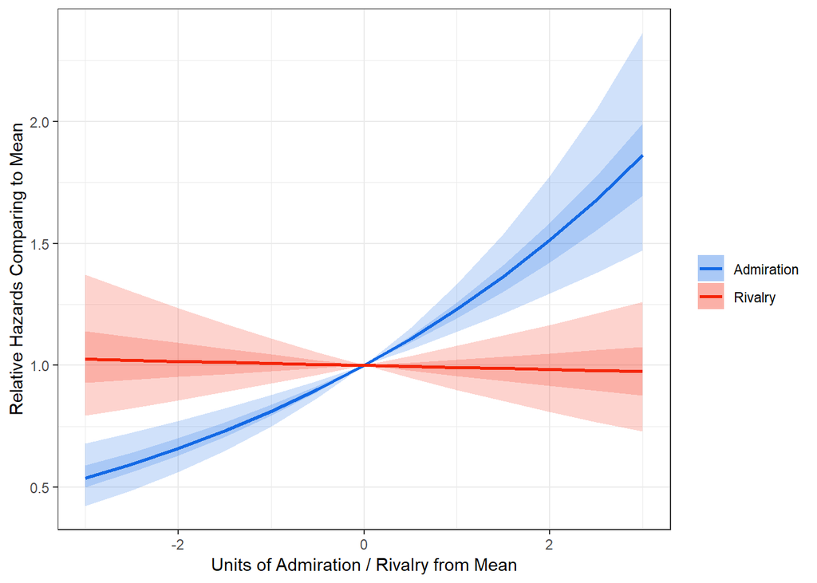

```r
Sim_rh_start_narq_con.riv = simGG(Sim_rh_start_narq_con.riv, xlab = "Units of rivalry from mean in SD", ylab = "Relative Hazards Comparing to Mean")

Sim_rh_start_narq_con.riv.data = Sim_rh_start_narq_con.riv$data %>%
  mutate(group = "Rivalry")

data_plot = bind_rows(Sim_rh_start_narq_con.adm.data, Sim_rh_start_narq_con.riv.data)

ggplot(data_plot, aes(Xj, Median, fill = group)) +
  geom_ribbon(aes(ymin = Min, ymax = Max), alpha = 0.2) +
  geom_ribbon(aes(ymin = Lower50, ymax = Upper50), alpha = 0.2) +
  geom_line(size = 1, aes(color = group)) +
  labs(x = "Units of Admiration / Rivalry from Mean",
       y = "Relative Hazards Comparing to Mean",
       fill = "", color = "") +
  scale_color_manual(values=c("#1369E5", "#F42509")) +
  scale_fill_manual(values=c("#1369E5", "#F42509")) +
  theme_bw()
```

### Model 3

rel_entry ~ NARQ_ADM_z + NARQ_RIV_z + gender/sex + age + cluster(session)

```r
start_narq_con.3 <- coxph(Surv(single_start_d, single_end_d, event_start) ~
                            NARQ_ADM_z + NARQ_RIV_z + sex + age +cluster(session), data = surv_data)
summary(start_narq_con.3)
```

```
## Call:
## coxph(formula = Surv(single_start_d, single_end_d, event_start) ~
##     NARQ_ADM_z + NARQ_RIV_z + sex + age + cluster(session), data = surv_data)
##
##   n= 1171, number of events= 621
##
##                 coef exp(coef)  se(coef) robust se      z Pr(>|z|)
## NARQ_ADM_z  0.189184  1.208263  0.041762  0.044780  4.225 2.39e-05 ***
## NARQ_RIV_z -0.015465  0.984654  0.042425  0.047548 -0.325    0.745
## sex         0.002163  1.002165  0.085599  0.093271  0.023    0.981
## age        -0.052340  0.949006  0.005672  0.006102 -8.578  < 2e-16 ***
## ---
## Signif. codes:  0 '***' 0.001 '**' 0.01 '*' 0.05 '.' 0.1 ' ' 1
##
##            exp(coef) exp(-coef) lower .95 upper .95
## NARQ_ADM_z    1.2083     0.8276    1.1067    1.3191
## NARQ_RIV_z    0.9847     1.0156    0.8970    1.0808
## sex           1.0022     0.9978    0.8347    1.2032
## age           0.9490     1.0537    0.9377    0.9604
##
## Concordance= 0.615  (se = 0.013 )
## Rsquare= 0.114   (max possible= 0.999 )
## Likelihood ratio test= 141.7  on 4 df,   p=<2e-16
## Wald test            = 97.75  on 4 df,   p=<2e-16
## Score (logrank) test = 116.1  on 4 df,   p=<2e-16,   Robust = 97.27  p=<2e-16
##
##   (Note: the likelihood ratio and score tests assume independence of
##      observations within a cluster, the Wald and robust score tests do not).
```

```r
## Should not be significant
cox.zph(start_narq_con.3)
```

```
##                rho  chisq     p
## NARQ_ADM_z 0.00807 0.0479 0.827
## NARQ_RIV_z 0.00755 0.0496 0.824
## sex        0.01447 0.1624 0.687
## age        0.02743 0.6176 0.432
## GLOBAL          NA 0.9373 0.919
```

```r
testPH_start_narq_con.3 <- ggcoxzph(cox.zph(start_narq_con.3))
```

### Plot Relative Hazards for ADM und RIV

```r
rh_start_narq_con.2 <- coxph(Surv(single_start_d, single_end_d, event_start) ~
                            NARQ_ADM_z + NARQ_RIV_z + sex + age + cluster(session), data = surv_data)

Sim_rh_start_narq_con.adm <- coxsimLinear(rh_start_narq_con.2, b = "NARQ_ADM_z",
                                        Xj = seq(-3, 3, by = 0.5), nsim = 100)
```

```
## All Xl set to 0.
```

```r
Sim_rh_start_narq_con.adm = simGG(Sim_rh_start_narq_con.adm, xlab = "Units of admiration from mean in SD", ylab = "Relative Hazards Comparing to Mean")

Sim_rh_start_narq_con.adm.data = Sim_rh_start_narq_con.adm$data %>%
  mutate(group = "Admiration")

Sim_rh_start_narq_con.riv <- coxsimLinear(rh_start_narq_con.2, b = "NARQ_RIV_z",
                                        Xj = seq(-3, 3, by = 0.5), nsim = 100)
```

```
## All Xl set to 0.
```

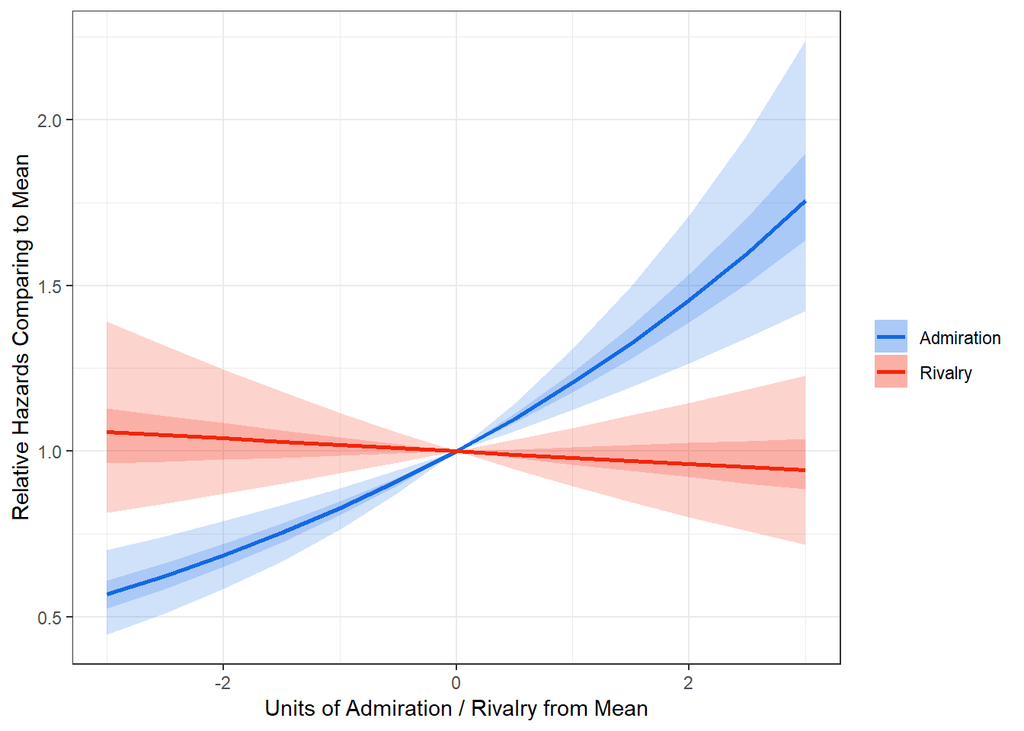

```r
Sim_rh_start_narq_con.riv = simGG(Sim_rh_start_narq_con.riv, xlab = "Units of rivalry from mean in SD", ylab = "Relative Hazards Comparing to Mean")

Sim_rh_start_narq_con.riv.data = Sim_rh_start_narq_con.riv$data %>%
  mutate(group = "Rivalry")

data_plot = bind_rows(Sim_rh_start_narq_con.adm.data, Sim_rh_start_narq_con.riv.data)

ggplot(data_plot, aes(Xj, Median, fill = group)) +
  geom_ribbon(aes(ymin = Min, ymax = Max), alpha = 0.2) +
  geom_ribbon(aes(ymin = Lower50, ymax = Upper50), alpha = 0.2) +
  geom_line(size = 1, aes(color = group)) +
  labs(x = "Units of Admiration / Rivalry from Mean",
       y = "Relative Hazards Comparing to Mean",
       fill = "", color = "") +
  scale_color_manual(values=c("#1369E5", "#F42509")) +
  scale_fill_manual(values=c("#1369E5", "#F42509")) +
  theme_bw()
```

### Model 4

rel_entry ~ NARQ_ADM_group + NARQ_RIV_group + gender/sex + age + cluster(session)

```r
start_narq_group <- coxph(Surv(single_start_d, single_end_d, event_start) ~
                            NARQ_ADM_group + NARQ_RIV_group + sex + age + cluster(session),
                          data = surv_data)
summary(start_narq_group)
```

```
## Call:
## coxph(formula = Surv(single_start_d, single_end_d, event_start) ~
##     NARQ_ADM_group + NARQ_RIV_group + sex + age + cluster(session),
##     data = surv_data)
##
##   n= 1171, number of events= 621
##
##                        coef exp(coef)  se(coef) robust se      z Pr(>|z|)
## NARQ_ADM_grouplow -0.296677  0.743284  0.081269  0.087318 -3.398  0.00068
## NARQ_RIV_grouplow -0.047386  0.953719  0.082310  0.088651 -0.535  0.59298
## sex                0.010111  1.010163  0.084907  0.092335  0.110  0.91280
## age               -0.052661  0.948701  0.005640  0.006046 -8.710  < 2e-16
##
## NARQ_ADM_grouplow ***
## NARQ_RIV_grouplow
## sex
## age               ***
## ---
## Signif. codes:  0 '***' 0.001 '**' 0.01 '*' 0.05 '.' 0.1 ' ' 1
##
##                   exp(coef) exp(-coef) lower .95 upper .95
## NARQ_ADM_grouplow    0.7433     1.3454    0.6264     0.882
## NARQ_RIV_grouplow    0.9537     1.0485    0.8016     1.135
## sex                  1.0102     0.9899    0.8429     1.211
## age                  0.9487     1.0541    0.9375     0.960
##
## Concordance= 0.613  (se = 0.013 )
## Rsquare= 0.109   (max possible= 0.999 )
## Likelihood ratio test= 135.3  on 4 df,   p=<2e-16
## Wald test            = 91.23  on 4 df,   p=<2e-16
## Score (logrank) test = 110.2  on 4 df,   p=<2e-16,   Robust = 95.24  p=<2e-16
##
##   (Note: the likelihood ratio and score tests assume independence of
##      observations within a cluster, the Wald and robust score tests do not).
```

```r
## Should not be significant
cox.zph(start_narq_con.2)
```

```
##                 rho  chisq     p
## NARQ_ADM_z  0.02891 0.6199 0.431
## NARQ_RIV_z -0.00391 0.0127 0.910
## GLOBAL           NA 0.6202 0.733
```

```r
testPH_start_narq_con.2 <- ggcoxzph(cox.zph(start_narq_con.2))
```

### Plot survival analysis for groups

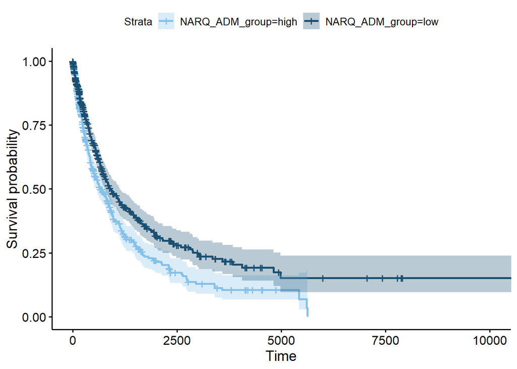

```r
plot_model1 = survfit(Surv(single_start_d, single_end_d, event_start) ~
                            NARQ_ADM_group + cluster(session),
                          data = surv_data)

ggsurvplot(plot_model1, conf.int = T, palette = c("#85C1E9", "#1B4F72"))
```

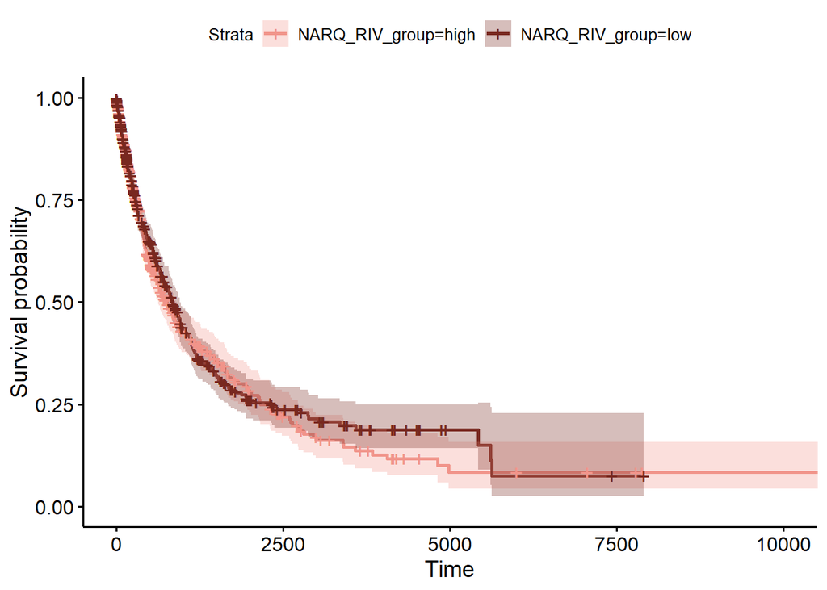

```r
plot_model2 = survfit(Surv(single_start_d, single_end_d, event_start) ~
                            NARQ_RIV_group + cluster(session),
                          data = surv_data)

ggsurvplot(plot_model2, conf.int = T, palette = c("#F1948A", "#78281F"))
```

### Model 5

rel_entry ~ NARQ_ADM_quartil + NARQ_RIV_quartil + gender/sex + age + cluster(session)

```r
start_narq_quartil <- coxph(Surv(single_start_d, single_end_d, event_start) ~
                            NARQ_ADM_quartil + NARQ_RIV_quartil + sex + age + cluster(session),
                          data = surv_data)
summary(start_narq_quartil)
```

```
## Call:
## coxph(formula = Surv(single_start_d, single_end_d, event_start) ~
##     NARQ_ADM_quartil + NARQ_RIV_quartil + sex + age + cluster(session),
##     data = surv_data)
##
##   n= 1171, number of events= 621
##
##                        coef exp(coef)  se(coef) robust se      z Pr(>|z|)
## NARQ_ADM_quartil2  0.181660  1.199206  0.117394  0.126775  1.433 0.151876
## NARQ_ADM_quartil3  0.310156  1.363638  0.112426  0.121271  2.558 0.010541
## NARQ_ADM_quartil4  0.498685  1.646554  0.119787  0.133284  3.742 0.000183
## NARQ_RIV_quartil2 -0.085955  0.917636  0.116393  0.127557 -0.674 0.500404
## NARQ_RIV_quartil3  0.011079  1.011140  0.110828  0.117298  0.094 0.924753
## NARQ_RIV_quartil4 -0.027633  0.972746  0.111860  0.122182 -0.226 0.821077
## sex                0.010099  1.010150  0.086090  0.093801  0.108 0.914260
## age               -0.052654  0.948709  0.005649  0.006042 -8.714  < 2e-16
##
## NARQ_ADM_quartil2
## NARQ_ADM_quartil3 *
## NARQ_ADM_quartil4 ***
## NARQ_RIV_quartil2
## NARQ_RIV_quartil3
## NARQ_RIV_quartil4
## sex
## age               ***
## ---
## Signif. codes:  0 '***' 0.001 '**' 0.01 '*' 0.05 '.' 0.1 ' ' 1
##
##                   exp(coef) exp(-coef) lower .95 upper .95
## NARQ_ADM_quartil2    1.1992     0.8339    0.9354     1.537
## NARQ_ADM_quartil3    1.3636     0.7333    1.0752     1.730
## NARQ_ADM_quartil4    1.6466     0.6073    1.2680     2.138
## NARQ_RIV_quartil2    0.9176     1.0898    0.7147     1.178
## NARQ_RIV_quartil3    1.0111     0.9890    0.8035     1.272
## NARQ_RIV_quartil4    0.9727     1.0280    0.7656     1.236
## sex                  1.0102     0.9900    0.8405     1.214
## age                  0.9487     1.0541    0.9375     0.960
##
## Concordance= 0.617  (se = 0.013 )
## Rsquare= 0.114   (max possible= 0.999 )
## Likelihood ratio test= 141.1  on 8 df,   p=<2e-16
## Wald test            = 95.94  on 8 df,   p=<2e-16
## Score (logrank) test = 116.8  on 8 df,   p=<2e-16,   Robust = 97.76  p=<2e-16
##
##   (Note: the likelihood ratio and score tests assume independence of
##      observations within a cluster, the Wald and robust score tests do not).
```

```r
## Should not be significant
cox.zph(start_narq_quartil)
```

```
##                        rho  chisq     p
## NARQ_ADM_quartil2  0.03742 1.0282 0.311
## NARQ_ADM_quartil3  0.04277 1.3459 0.246
## NARQ_ADM_quartil4 -0.00357 0.0098 0.921
## NARQ_RIV_quartil2 -0.00392 0.0119 0.913
## NARQ_RIV_quartil3  0.03648 0.9542 0.329
## NARQ_RIV_quartil4  0.01754 0.2419 0.623
## sex                0.01453 0.1641 0.685
## age                0.01966 0.3119 0.576
## GLOBAL                  NA 4.6582 0.793
```

```r
testPH_start_narq_quartil <- ggcoxzph(cox.zph(start_narq_quartil))
```

### Plot survival analysis for quartils

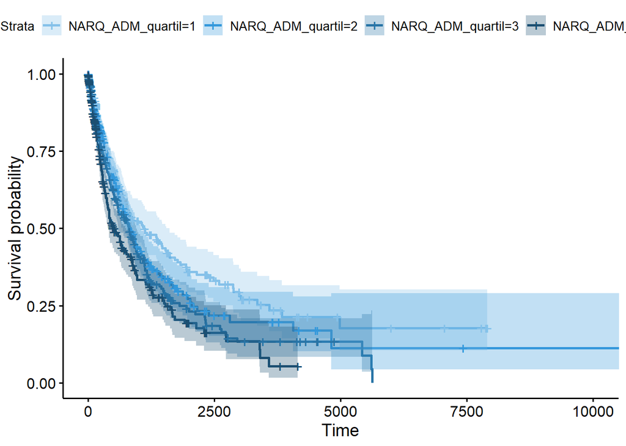

```r
plot_model1 = survfit(Surv(single_start_d, single_end_d, event_start) ~
                            NARQ_ADM_quartil + cluster(session),
                          data = surv_data)

ggsurvplot(plot_model1, conf.int = T, palette = c("#85C1E9", "#3498DB", "#2874A6", "#1B4F72"))
```

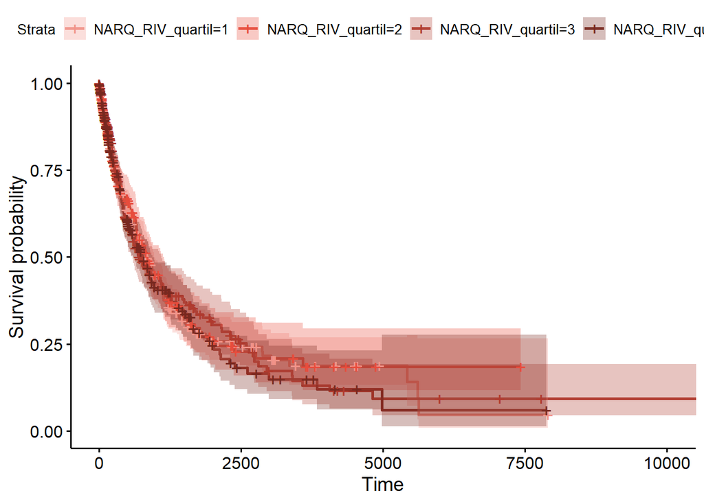

```r
plot_model2 = survfit(Surv(single_start_d, single_end_d, event_start) ~
                            NARQ_RIV_quartil + cluster(session),
                          data = surv_data)

ggsurvplot(plot_model2, conf.int = T, palette = c("#F1948A", "#E74C3C", "#B03A2E", "#78281F"))
```

### Model 6

rel_entry ~ NARQ_ADM_extreme + NARQ_RIV_extreme + gender/sex + age + cluster(session)

```r
start_narq_extreme <- coxph(Surv(single_start_d, single_end_d, event_start) ~
                            NARQ_ADM_extreme + NARQ_RIV_extreme + sex + age + cluster(session),
                          data = surv_data)
summary(start_narq_extreme)
```

```
## Call:
## coxph(formula = Surv(single_start_d, single_end_d, event_start) ~
##     NARQ_ADM_extreme + NARQ_RIV_extreme + sex + age + cluster(session),
##     data = surv_data)
##
##   n= 397, number of events= 213
##    (774 observations deleted due to missingness)
##
##                          coef exp(coef)  se(coef) robust se      z
## NARQ_ADM_extremelow -0.454969  0.634468  0.146328  0.158741 -2.866
## NARQ_RIV_extremelow  0.027677  1.028063  0.148620  0.157596  0.176
## sex                  0.081828  1.085269  0.148155  0.160157  0.511
## age                 -0.042953  0.957957  0.009578  0.010201 -4.211
##                     Pr(>|z|)
## NARQ_ADM_extremelow  0.00416 **
## NARQ_RIV_extremelow  0.86059
## sex                  0.60940
## age                 2.55e-05 ***
## ---
## Signif. codes:  0 '***' 0.001 '**' 0.01 '*' 0.05 '.' 0.1 ' ' 1
##
##                     exp(coef) exp(-coef) lower .95 upper .95
## NARQ_ADM_extremelow    0.6345     1.5761    0.4648    0.8660
## NARQ_RIV_extremelow    1.0281     0.9727    0.7549    1.4001
## sex                    1.0853     0.9214    0.7929    1.4855
## age                    0.9580     1.0439    0.9390    0.9773
##
## Concordance= 0.602  (se = 0.022 )
## Rsquare= 0.089   (max possible= 0.996 )
## Likelihood ratio test= 36.82  on 4 df,   p=2e-07
## Wald test            = 25.39  on 4 df,   p=4e-05
## Score (logrank) test = 31.94  on 4 df,   p=2e-06,   Robust = 26.31  p=3e-05
##
##   (Note: the likelihood ratio and score tests assume independence of
##      observations within a cluster, the Wald and robust score tests do not).
```

```r
## Should not be significant
cox.zph(start_narq_extreme)
```

```
##                         rho  chisq     p
## NARQ_ADM_extremelow -0.0156 0.0641 0.800
## NARQ_RIV_extremelow  0.0137 0.0454 0.831
## sex                 -0.0313 0.2471 0.619
## age                 -0.0479 0.6091 0.435
## GLOBAL                   NA 1.0239 0.906
```

```r
testPH_start_narq_extreme <- ggcoxzph(cox.zph(start_narq_extreme))
```

### Plot survival analysis for extremes

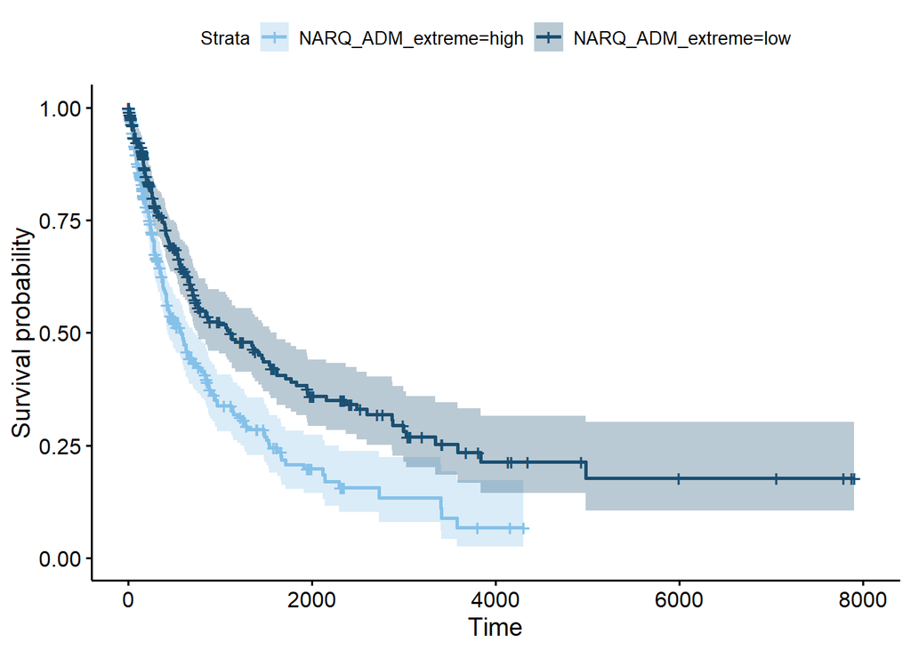

```r
plot_model1 = survfit(Surv(single_start_d, single_end_d, event_start) ~
                            NARQ_ADM_extreme + cluster(session),
                          data = surv_data)

ggsurvplot(plot_model1, conf.int = T, palette = c("#85C1E9", "#1B4F72"))
```

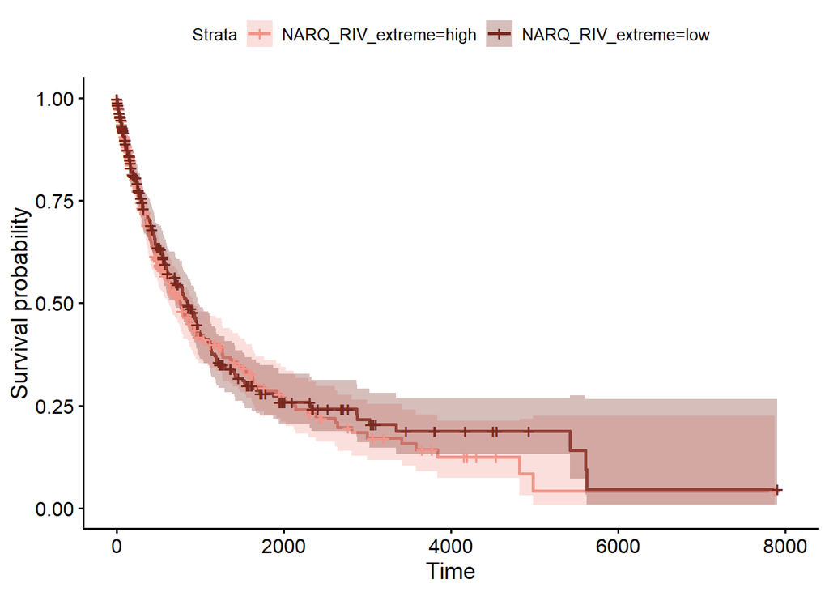

```r
plot_model2 = survfit(Surv(single_start_d, single_end_d, event_start) ~
                            NARQ_RIV_extreme + cluster(session),
                          data = surv_data)

ggsurvplot(plot_model2, conf.int = T, palette = c("#F1948A", "#78281F"))
```

## Relationship End

### Model 1

rel_end ~ NARQ_z + cluster(session)

```r
end_narq_con.1 <- coxph(Surv(rel_start_d, rel_end_d, event_end) ~
                            NARQ_scale_z + cluster(session), data = surv_data)

summary(end_narq_con.1)
```

```
## Call:
## coxph(formula = Surv(rel_start_d, rel_end_d, event_end) ~ NARQ_scale_z +
##     cluster(session), data = surv_data)
##
##   n= 621, number of events= 300
##    (550 observations deleted due to missingness)
##
##                 coef exp(coef) se(coef) robust se     z Pr(>|z|)
## NARQ_scale_z 0.10046   1.10567  0.05708   0.05446 1.845   0.0651 .
## ---
## Signif. codes:  0 '***' 0.001 '**' 0.01 '*' 0.05 '.' 0.1 ' ' 1
##
##              exp(coef) exp(-coef) lower .95 upper .95
## NARQ_scale_z     1.106     0.9044    0.9937      1.23
##
## Concordance= 0.535  (se = 0.018 )
## Rsquare= 0.005   (max possible= 0.996 )
## Likelihood ratio test= 3.05  on 1 df,   p=0.08
## Wald test            = 3.4  on 1 df,   p=0.07
## Score (logrank) test = 3.1  on 1 df,   p=0.08,   Robust = 3.19  p=0.07
##
##   (Note: the likelihood ratio and score tests assume independence of
##      observations within a cluster, the Wald and robust score tests do not).
```

```r
## Should not be significant
cox.zph(end_narq_con.1)
```

```
##                  rho    chisq    p
## NARQ_scale_z 0.00072 0.000147 0.99
```

```r
testPH_end_narq_con.1 <- ggcoxzph(cox.zph(end_narq_con.1))
```

### Model 2

rel_end ~ NARQ_ADM_z + NARQ_RIV_z + cluster(session)

```r
end_narq_con.2 <- coxph(Surv(rel_start_d, rel_end_d, event_end) ~
                            NARQ_ADM_z + NARQ_RIV_z + cluster(session), data = surv_data)

summary(end_narq_con.2)
```

```
## Call:
## coxph(formula = Surv(rel_start_d, rel_end_d, event_end) ~ NARQ_ADM_z +
##     NARQ_RIV_z + cluster(session), data = surv_data)
##
##   n= 621, number of events= 300
##    (550 observations deleted due to missingness)
##
##                coef exp(coef) se(coef) robust se      z Pr(>|z|)
## NARQ_ADM_z -0.03255   0.96797  0.05975   0.05511 -0.591  0.55476
## NARQ_RIV_z  0.15846   1.17170  0.05798   0.05652  2.804  0.00505 **
## ---
## Signif. codes:  0 '***' 0.001 '**' 0.01 '*' 0.05 '.' 0.1 ' ' 1
##
##            exp(coef) exp(-coef) lower .95 upper .95
## NARQ_ADM_z     0.968     1.0331    0.8689     1.078
## NARQ_RIV_z     1.172     0.8535    1.0488     1.309
##
## Concordance= 0.538  (se = 0.019 )
## Rsquare= 0.012   (max possible= 0.996 )
## Likelihood ratio test= 7.25  on 2 df,   p=0.03
## Wald test            = 7.88  on 2 df,   p=0.02
## Score (logrank) test = 7.5  on 2 df,   p=0.02,   Robust = 6.82  p=0.03
##
##   (Note: the likelihood ratio and score tests assume independence of
##      observations within a cluster, the Wald and robust score tests do not).
```

```r
## Should not be significant
cox.zph(end_narq_con.2)
```

```
##                rho  chisq     p
## NARQ_ADM_z -0.0173 0.0799 0.777
## NARQ_RIV_z  0.0207 0.1315 0.717
## GLOBAL          NA 0.1693 0.919
```

```r
testPH_end_narq_con.2 <- ggcoxzph(cox.zph(end_narq_con.2))
```

### Plot Relative Hazards for ADM und RIV

```r
rh_start_narq_con.2 <- coxph(Surv(rel_start_d, rel_end_d, event_end) ~
                            NARQ_ADM_z + NARQ_RIV_z + cluster(session), data = surv_data)

Sim_rh_start_narq_con.adm <- coxsimLinear(rh_start_narq_con.2, b = "NARQ_ADM_z",
                                        Xj = seq(-3, 3, by = 0.5), nsim = 100)
```

```
## All Xl set to 0.
```

```r
Sim_rh_start_narq_con.adm = simGG(Sim_rh_start_narq_con.adm, xlab = "Units of admiration from mean in SD", ylab = "Relative Hazards Comparing to Mean")

Sim_rh_start_narq_con.adm.data = Sim_rh_start_narq_con.adm$data %>%
  mutate(group = "Admiration")

Sim_rh_start_narq_con.riv <- coxsimLinear(rh_start_narq_con.2, b = "NARQ_RIV_z",
                                        Xj = seq(-3, 3, by = 0.5), nsim = 100)
```

```
## All Xl set to 0.
```

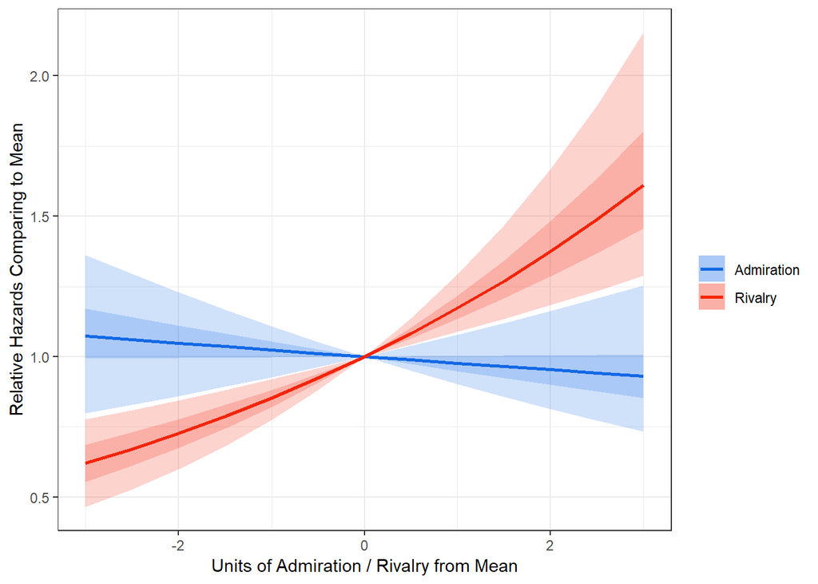

```r
Sim_rh_start_narq_con.riv = simGG(Sim_rh_start_narq_con.riv, xlab = "Units of rivalry from mean in SD", ylab = "Relative Hazards Comparing to Mean")

Sim_rh_start_narq_con.riv.data = Sim_rh_start_narq_con.riv$data %>%
  mutate(group = "Rivalry")

data_plot = bind_rows(Sim_rh_start_narq_con.adm.data, Sim_rh_start_narq_con.riv.data)

ggplot(data_plot, aes(Xj, Median, fill = group)) +
  geom_ribbon(aes(ymin = Min, ymax = Max), alpha = 0.2) +
  geom_ribbon(aes(ymin = Lower50, ymax = Upper50), alpha = 0.2) +
  geom_line(size = 1, aes(color = group)) +
  labs(x = "Units of Admiration / Rivalry from Mean",
       y = "Relative Hazards Comparing to Mean",
       fill = "", color = "") +
  scale_color_manual(values=c("#1369E5", "#F42509")) +
  scale_fill_manual(values=c("#1369E5", "#F42509")) +
  theme_bw()
```

### Model 3

rel_end ~ NARQ_ADM_z + NARQ_RIV_z + gender/sex + age + cluster(session)

```r
end_narq_con.3 <- coxph(Surv(rel_start_d, rel_end_d, event_end) ~
                            NARQ_ADM_z + NARQ_RIV_z + sex + age + cluster(session), data = surv_data)
summary(end_narq_con.3)
```

```
## Call:
## coxph(formula = Surv(rel_start_d, rel_end_d, event_end) ~ NARQ_ADM_z +
##     NARQ_RIV_z + sex + age + cluster(session), data = surv_data)
##
##   n= 621, number of events= 300
##    (550 observations deleted due to missingness)
##
##                 coef exp(coef)  se(coef) robust se      z Pr(>|z|)
## NARQ_ADM_z -0.044223  0.956741  0.059852  0.055431 -0.798  0.42498
## NARQ_RIV_z  0.148871  1.160523  0.058967  0.057227  2.601  0.00928 **
## sex         0.222862  1.249648  0.120305  0.114457  1.947  0.05152 .
## age        -0.001083  0.998918  0.007075  0.006145 -0.176  0.86013
## ---
## Signif. codes:  0 '***' 0.001 '**' 0.01 '*' 0.05 '.' 0.1 ' ' 1
##
##            exp(coef) exp(-coef) lower .95 upper .95
## NARQ_ADM_z    0.9567     1.0452    0.8582     1.067
## NARQ_RIV_z    1.1605     0.8617    1.0374     1.298
## sex           1.2496     0.8002    0.9985     1.564
## age           0.9989     1.0011    0.9870     1.011
##
## Concordance= 0.555  (se = 0.019 )
## Rsquare= 0.017   (max possible= 0.996 )
## Likelihood ratio test= 10.64  on 4 df,   p=0.03
## Wald test            = 10.11  on 4 df,   p=0.04
## Score (logrank) test = 10.93  on 4 df,   p=0.03,   Robust = 8.89  p=0.06
##
##   (Note: the likelihood ratio and score tests assume independence of
##      observations within a cluster, the Wald and robust score tests do not).
```

```r
## Should not be significant
cox.zph(end_narq_con.3)
```

```
##                rho  chisq      p
## NARQ_ADM_z -0.0145 0.0579 0.8098
## NARQ_RIV_z  0.0236 0.1821 0.6696
## sex        -0.1331 4.9795 0.0256
## age         0.0908 1.9843 0.1589
## GLOBAL          NA 6.6308 0.1567
```

```r
testPH_end_narq_con.3 <- ggcoxzph(cox.zph(end_narq_con.3))
```

### Plot Relative Hazards for ADM und RIV

```r
rh_start_narq_con.2 <- coxph(Surv(rel_start_d, rel_end_d, event_end) ~
                            NARQ_ADM_z + NARQ_RIV_z + sex + age + cluster(session), data = surv_data)

Sim_rh_start_narq_con.adm <- coxsimLinear(rh_start_narq_con.2, b = "NARQ_ADM_z",
                                        Xj = seq(-3, 3, by = 0.5), nsim = 100)
```

```
## All Xl set to 0.
```

```r
Sim_rh_start_narq_con.adm = simGG(Sim_rh_start_narq_con.adm, xlab = "Units of admiration from mean in SD", ylab = "Relative Hazards Comparing to Mean")

Sim_rh_start_narq_con.adm.data = Sim_rh_start_narq_con.adm$data %>%
  mutate(group = "Admiration")

Sim_rh_start_narq_con.riv <- coxsimLinear(rh_start_narq_con.2, b = "NARQ_RIV_z",
                                        Xj = seq(-3, 3, by = 0.5), nsim = 100)
```

```
## All Xl set to 0.
```

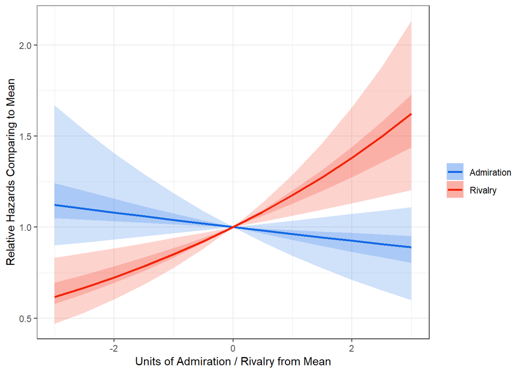

```r
Sim_rh_start_narq_con.riv = simGG(Sim_rh_start_narq_con.riv, xlab = "Units of rivalry from mean in SD", ylab = "Relative Hazards Comparing to Mean")

Sim_rh_start_narq_con.riv.data = Sim_rh_start_narq_con.riv$data %>%
  mutate(group = "Rivalry")

data_plot = bind_rows(Sim_rh_start_narq_con.adm.data, Sim_rh_start_narq_con.riv.data)

ggplot(data_plot, aes(Xj, Median, fill = group)) +
  geom_ribbon(aes(ymin = Min, ymax = Max), alpha = 0.2) +
  geom_ribbon(aes(ymin = Lower50, ymax = Upper50), alpha = 0.2) +
  geom_line(size = 1, aes(color = group)) +
  labs(x = "Units of Admiration / Rivalry from Mean",
       y = "Relative Hazards Comparing to Mean",
       fill = "", color = "") +
  scale_color_manual(values=c("#1369E5", "#F42509")) +
  scale_fill_manual(values=c("#1369E5", "#F42509")) +
  theme_bw()
```

### Model 4

rel_end ~ NARQ_ADM_group + NARQ_RIV_group + gender/sex + age + cluster(session)

```r
end_narq_group <- coxph(Surv(rel_start_d, rel_end_d, event_end) ~
                            NARQ_ADM_group + NARQ_RIV_group + sex + age + cluster(session),
                          data = surv_data)
summary(end_narq_group)
```

```
## Call:
## coxph(formula = Surv(rel_start_d, rel_end_d, event_end) ~ NARQ_ADM_group +
##     NARQ_RIV_group + sex + age + cluster(session), data = surv_data)
##
##   n= 621, number of events= 300
##    (550 observations deleted due to missingness)
##
##                        coef exp(coef)  se(coef) robust se      z Pr(>|z|)
## NARQ_ADM_grouplow -0.080006  0.923111  0.117887  0.112772 -0.709   0.4780
## NARQ_RIV_grouplow -0.202678  0.816541  0.118654  0.110970 -1.826   0.0678
## sex                0.209621  1.233210  0.120524  0.114115  1.837   0.0662
## age               -0.002676  0.997328  0.007028  0.006052 -0.442   0.6584
##
## NARQ_ADM_grouplow
## NARQ_RIV_grouplow .
## sex               .
## age
## ---
## Signif. codes:  0 '***' 0.001 '**' 0.01 '*' 0.05 '.' 0.1 ' ' 1
##
##                   exp(coef) exp(-coef) lower .95 upper .95
## NARQ_ADM_grouplow    0.9231     1.0833    0.7401     1.151
## NARQ_RIV_grouplow    0.8165     1.2247    0.6569     1.015
## sex                  1.2332     0.8109    0.9861     1.542
## age                  0.9973     1.0027    0.9856     1.009
##
## Concordance= 0.562  (se = 0.019 )
## Rsquare= 0.013   (max possible= 0.996 )
## Likelihood ratio test= 8.2  on 4 df,   p=0.08
## Wald test            = 7.89  on 4 df,   p=0.1
## Score (logrank) test = 8.32  on 4 df,   p=0.08,   Robust = 7.56  p=0.1
##
##   (Note: the likelihood ratio and score tests assume independence of
##      observations within a cluster, the Wald and robust score tests do not).
```

```r
## Should not be significant
cox.zph(end_narq_group)
```

```
##                       rho chisq      p
## NARQ_ADM_grouplow  0.0975  2.74 0.0976
## NARQ_RIV_grouplow -0.0358  0.36 0.5485
## sex               -0.1393  5.33 0.0209
## age                0.1007  2.43 0.1192
## GLOBAL                 NA  9.41 0.0516
```

```r
testPH_end_narq_group <- ggcoxzph(cox.zph(end_narq_group))
```

### Plot survival analysis for groups

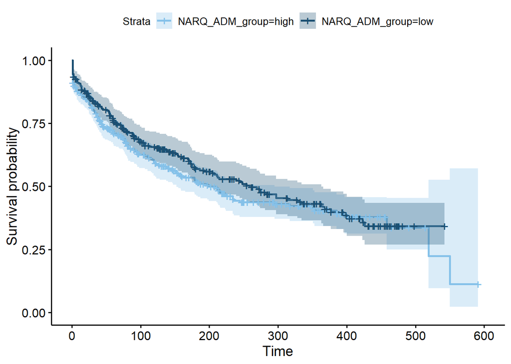

```r
plot_model1 = survfit(Surv(rel_start_d, rel_end_d, event_end) ~
                            NARQ_ADM_group + cluster(session),
                          data = surv_data)

ggsurvplot(plot_model1, conf.int = T, palette = c("#85C1E9", "#1B4F72"))
```

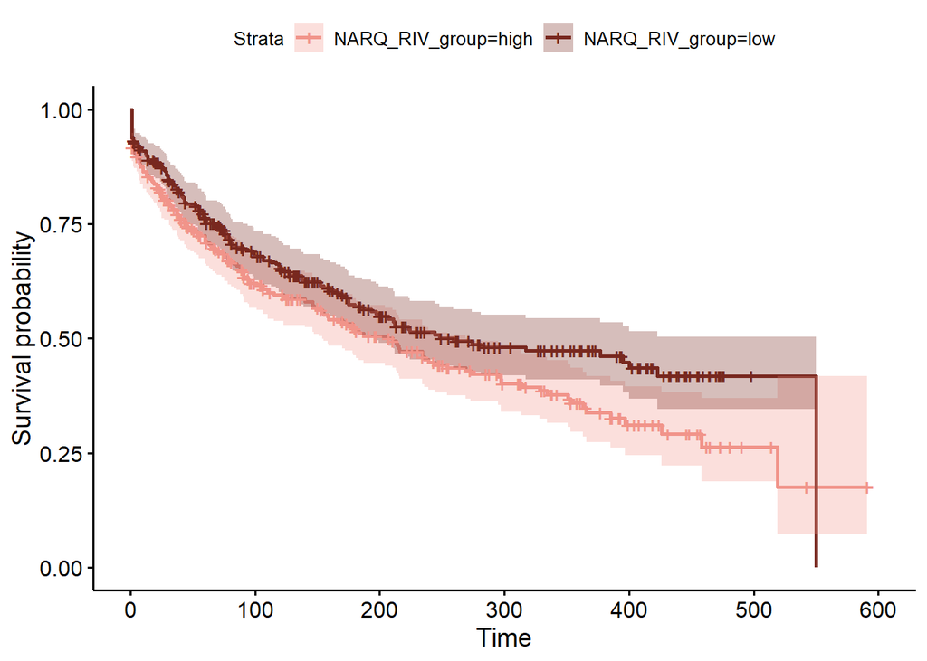

```r
plot_model2 = survfit(Surv(rel_start_d, rel_end_d, event_end) ~
                            NARQ_RIV_group + cluster(session),
                          data = surv_data)

ggsurvplot(plot_model2, conf.int = T, palette = c("#F1948A", "#78281F"))
```

### Model 5

rel_end ~ NARQ_ADM_quartil + NARQ_RIV_quartil + gender/sex + age + cluster(session)

```r
end_narq_quartil <- coxph(Surv(rel_start_d, rel_end_d, event_end) ~
                            NARQ_ADM_quartil + NARQ_RIV_quartil + sex + age + cluster(session),
                          data = surv_data)
summary(end_narq_quartil)
```

```
## Call:
## coxph(formula = Surv(rel_start_d, rel_end_d, event_end) ~ NARQ_ADM_quartil +
##     NARQ_RIV_quartil + sex + age + cluster(session), data = surv_data)
##
##   n= 621, number of events= 300
##    (550 observations deleted due to missingness)
##
##                        coef exp(coef)  se(coef) robust se      z Pr(>|z|)
## NARQ_ADM_quartil2 -0.132037  0.876309  0.170589  0.160281 -0.824   0.4101
## NARQ_ADM_quartil3 -0.004607  0.995404  0.162311  0.166089 -0.028   0.9779
## NARQ_ADM_quartil4  0.017184  1.017333  0.169333  0.162373  0.106   0.9157
## NARQ_RIV_quartil2 -0.106384  0.899079  0.175850  0.164384 -0.647   0.5175
## NARQ_RIV_quartil3  0.049584  1.050834  0.159372  0.144027  0.344   0.7306
## NARQ_RIV_quartil4  0.275732  1.317494  0.159061  0.157098  1.755   0.0792
## sex                0.206849  1.229797  0.121154  0.115356  1.793   0.0730
## age               -0.002312  0.997691  0.007070  0.006189 -0.374   0.7088
##
## NARQ_ADM_quartil2
## NARQ_ADM_quartil3
## NARQ_ADM_quartil4
## NARQ_RIV_quartil2
## NARQ_RIV_quartil3
## NARQ_RIV_quartil4 .
## sex               .
## age
## ---
## Signif. codes:  0 '***' 0.001 '**' 0.01 '*' 0.05 '.' 0.1 ' ' 1
##
##                   exp(coef) exp(-coef) lower .95 upper .95
## NARQ_ADM_quartil2    0.8763     1.1412    0.6401     1.200
## NARQ_ADM_quartil3    0.9954     1.0046    0.7188     1.378
## NARQ_ADM_quartil4    1.0173     0.9830    0.7400     1.399
## NARQ_RIV_quartil2    0.8991     1.1122    0.6514     1.241
## NARQ_RIV_quartil3    1.0508     0.9516    0.7924     1.394
## NARQ_RIV_quartil4    1.3175     0.7590    0.9683     1.793
## sex                  1.2298     0.8131    0.9809     1.542
## age                  0.9977     1.0023    0.9857     1.010
##
## Concordance= 0.562  (se = 0.019 )
## Rsquare= 0.018   (max possible= 0.996 )
## Likelihood ratio test= 11.12  on 8 df,   p=0.2
## Wald test            = 10.87  on 8 df,   p=0.2
## Score (logrank) test = 11.5  on 8 df,   p=0.2,   Robust = 10.19  p=0.3
##
##   (Note: the likelihood ratio and score tests assume independence of
##      observations within a cluster, the Wald and robust score tests do not).
```

```r
## Should not be significant
cox.zph(end_narq_quartil)
```

```
##                       rho   chisq       p
## NARQ_ADM_quartil2 -0.0208  0.1238 0.72498
## NARQ_ADM_quartil3 -0.1465  7.0404 0.00797
## NARQ_ADM_quartil4 -0.0116  0.0406 0.84032
## NARQ_RIV_quartil2  0.0969  2.4423 0.11810
## NARQ_RIV_quartil3  0.0548  0.7832 0.37615
## NARQ_RIV_quartil4  0.0452  0.6495 0.42028
## sex               -0.1621  7.3774 0.00660
## age                0.1143  3.1776 0.07465
## GLOBAL                 NA 18.5259 0.01761
```

```r
testPH_end_narq_quartil <- ggcoxzph(cox.zph(end_narq_quartil))
```

### Plot survival analysis for quartils

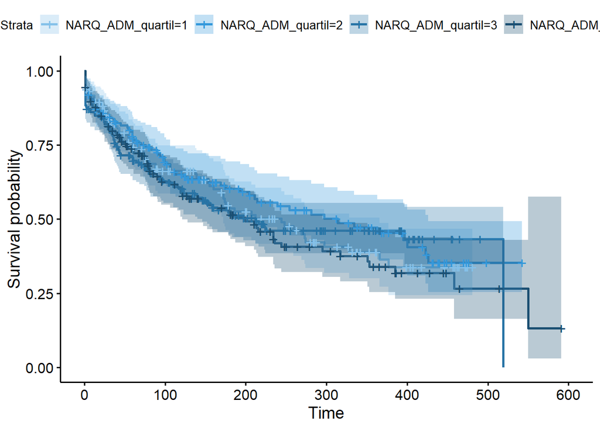

```r
plot_model1 = survfit(Surv(rel_start_d, rel_end_d, event_end) ~
                            NARQ_ADM_quartil + cluster(session),
                          data = surv_data)

ggsurvplot(plot_model1, conf.int = T, palette = c("#85C1E9", "#3498DB", "#2874A6", "#1B4F72"))
```

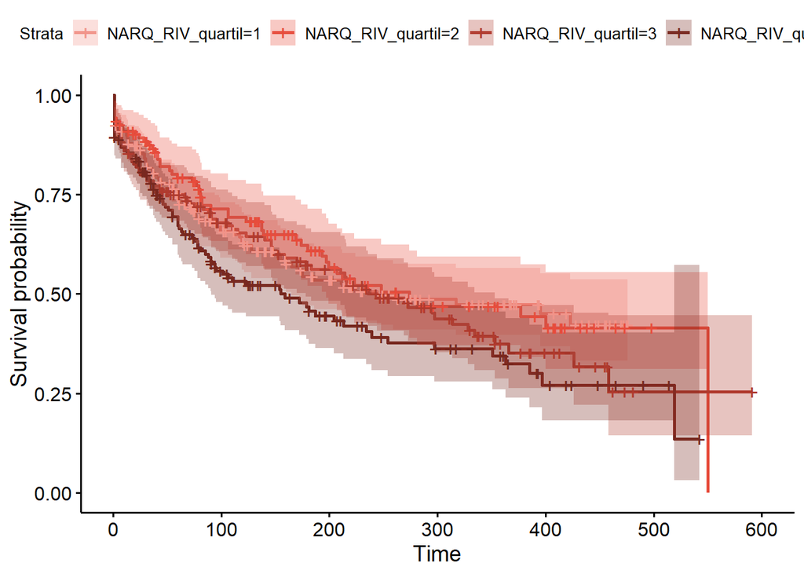

```r
plot_model2 = survfit(Surv(rel_start_d, rel_end_d, event_end) ~
                            NARQ_RIV_quartil + cluster(session),
                          data = surv_data)

ggsurvplot(plot_model2, conf.int = T, palette = c("#F1948A", "#E74C3C", "#B03A2E", "#78281F"))
```

### Model 6

rel_end ~ NARQ_ADM_extreme + NARQ_RIV_extreme + gender/sex + age + cluster(session)

```r
end_narq_extreme <- coxph(Surv(rel_start_d, rel_end_d, event_end) ~
                            NARQ_ADM_extreme + NARQ_RIV_extreme + sex + age + cluster(session),
                          data = surv_data)
summary(end_narq_extreme)
```

```
## Call:
## coxph(formula = Surv(rel_start_d, rel_end_d, event_end) ~ NARQ_ADM_extreme +
##     NARQ_RIV_extreme + sex + age + cluster(session), data = surv_data)
##
##   n= 213, number of events= 106
##    (958 observations deleted due to missingness)
##
##                          coef exp(coef)  se(coef) robust se      z
## NARQ_ADM_extremelow  0.147161  1.158540  0.206079  0.211532  0.696
## NARQ_RIV_extremelow -0.438538  0.644979  0.216579  0.199821 -2.195
## sex                  0.164920  1.179299  0.204708  0.193161  0.854
## age                  0.003042  1.003046  0.011448  0.009478  0.321
##                     Pr(>|z|)
## NARQ_ADM_extremelow   0.4866
## NARQ_RIV_extremelow   0.0282 *
## sex                   0.3932
## age                   0.7483
## ---
## Signif. codes:  0 '***' 0.001 '**' 0.01 '*' 0.05 '.' 0.1 ' ' 1
##
##                     exp(coef) exp(-coef) lower .95 upper .95
## NARQ_ADM_extremelow     1.159     0.8632    0.7653    1.7537
## NARQ_RIV_extremelow     0.645     1.5504    0.4360    0.9542
## sex                     1.179     0.8480    0.8076    1.7220
## age                     1.003     0.9970    0.9846    1.0219
##
## Concordance= 0.561  (se = 0.031 )
## Rsquare= 0.028   (max possible= 0.991 )
## Likelihood ratio test= 5.94  on 4 df,   p=0.2
## Wald test            = 5.31  on 4 df,   p=0.3
## Score (logrank) test = 5.93  on 4 df,   p=0.2,   Robust = 4.98  p=0.3
##
##   (Note: the likelihood ratio and score tests assume independence of
##      observations within a cluster, the Wald and robust score tests do not).
```

```r
## Should not be significant
cox.zph(end_narq_extreme)
```

```
##                         rho chisq     p
## NARQ_ADM_extremelow  0.0489  0.31 0.578
## NARQ_RIV_extremelow -0.1037  1.21 0.272
## sex                 -0.1215  1.51 0.219
## age                  0.2518  5.70 0.017
## GLOBAL                   NA  6.76 0.149
```

```r
testPH_end_narq_extreme <- ggcoxzph(cox.zph(end_narq_extreme))
```

### Plot survival analysis for extremes

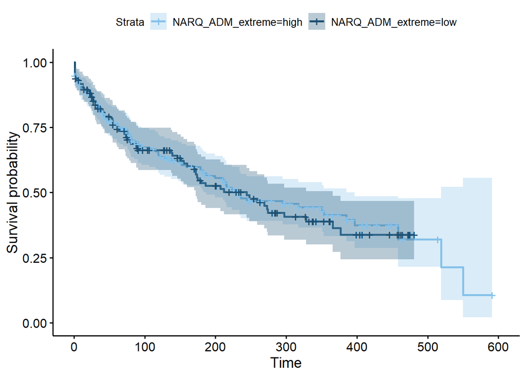

```r
plot_model1 = survfit(Surv(rel_start_d, rel_end_d, event_end) ~
                            NARQ_ADM_extreme + cluster(session),
                          data = surv_data)

ggsurvplot(plot_model1, conf.int = T, palette = c("#85C1E9", "#1B4F72"))
```

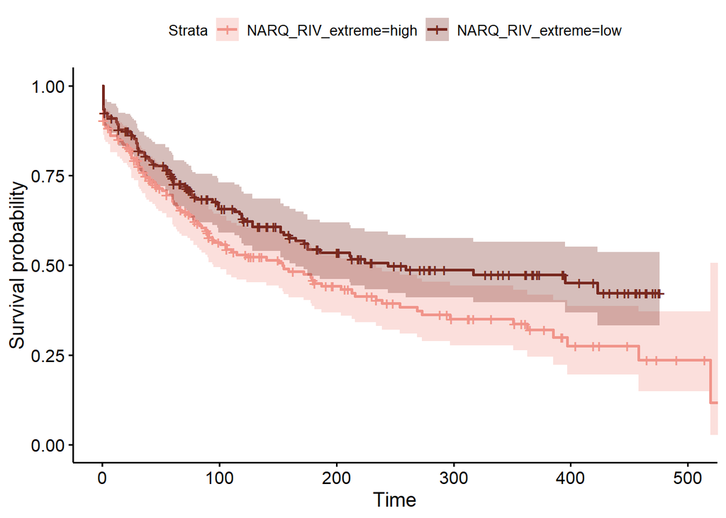

```r
plot_model2 = survfit(Surv(rel_start_d, rel_end_d, event_end) ~
                            NARQ_RIV_extreme + cluster(session),
                          data = surv_data)

ggsurvplot(plot_model2, conf.int = T, palette = c("#F1948A", "#78281F"))
```